# Covid-19 Deaths Before and After Vaccine

Author: Rick Dean

Article date: 2022-01-07

Abstract

## Read the data

Note: Table shows a portion (8 rows) of the data.

```r
current_dir = here()
data_file_path = file.path(current_dir, "data", "data.csv")
data_df = data.table::fread(data_file_path)
RplotterPkg::create_table(
  x = head(data_df,8),
  caption = "Percentage of Deaths",
  font_size = 14,
  align_v = c("l","c","c","c"),
)
```

Percentage of Deaths

| race | age_group | before | after |
| --- | --- | --- | --- |
| white | under_25 | 1 | 3 |
| white | 25-44 | 3 | 10 |
| white | 45-64 | 8 | 15 |
| white | 65-84 | 13 | 11 |
| white | 85+ | 14 | 6 |
| hispanic | under_25 | 3 | 4 |
| hispanic | 25-44 | 17 | 21 |
| hispanic | 45-64 | 33 | 26 |

## Create a data.table

1. “Melt” the `before` and `after` columns into one column:

```r
data_long_df = data.table::melt(data_df, measure.vars = c("before","after"), variable.name = "eligibility", value.name = "percent of deaths")
```

2. Define `age_group` column as a factor with a specific order. Also append the numeric `elig` column reflecting values `before` and `after` values as 0 or 1 respectively:

```r
data_long_df[, `:=`(age_group = factor(age_group, levels = c("under_25","25-44","45-64","65-84","85+")), elig = ifelse(eligibility == "before", 0,1))]
```

## Create a list of `RplotterPkg::multi_scatter_plot()` objects for each race

Note: Each of the 4 race `multi_scatter_plot()`’s contains 5 line graphs for each age group of the race.

```r
races <-  c("white", "hispanic", "black", "asian")
plots_lst <-  vector(mode = "list", length = length(races))
for(i in seq_along(races)){
  data_race_df <-  data_long_df[race == races[[i]]]

  plots_lst[[i]] <- RplotterPkg::multi_scatter_plot(
    df = data_race_df,
    title = races[[i]],
    factor_var = "age_group",
    factor_x = "elig",
    x_major_breaks = c(0,1),
    x_labels = c("before", "after"),
    aes_y = "percent of deaths",
    columns = 5,
    col_width = 2,
    row_height = 3,
    connect = TRUE,
    line_color = "blue",
    y_limits = c(0, 40),
    y_major_breaks =  seq(from = 0, to = 40, by = 10),
    rot_y_tic_label = TRUE,
    aes_label = "percent of deaths",
    aes_label_nudge_x = 0.1,
    aes_label_nudge_y = 2.0,
    display_plot = FALSE
  )
}
```

## Consolidate the 4 race `RplotterPkg::multi_scatter_plot()` objects into one plot

Note: Using `RplotterPkg::multi_panel_grid()` to layout the 4 race plots into one plot.

1. Define a layout by specifying 4 race plots, 1 column and 4 rows:

```r
layout_lst  <-  list(
  "plots" = plots_lst,
  "rows" =  c(1, 2, 3, 4),
  "cols" =  c(1, 1, 1, 1)
)
```

2. Create a consolidated plot 12 inches wide with each race row taking up 3.5 inches along with a title:

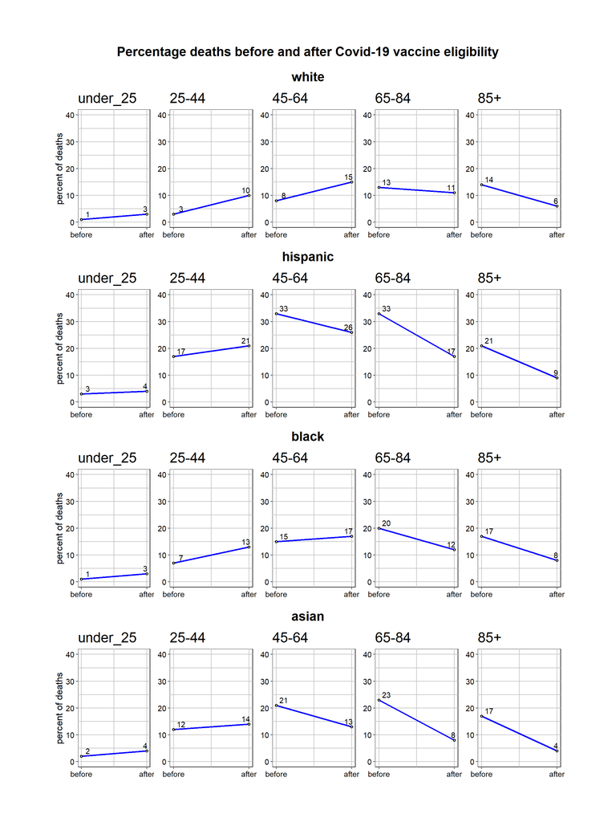

```r
plot_table <- RplotterPkg::multi_panel_grid(
  layout = layout_lst,
  col_widths =  12,
  row_heights = c(3.5,3.5,3.5,3.5),
  title = "Percentage deaths before and after Covid-19 vaccine eligibility"
)
```